## Assignment 10

#### Due Friday, November 17, 11:59 PM CT

### Preliminaries

- Directories
  - COURSE/homework/
  - COURSE/homework/hw10/
  - COURSE/data/
  - COURSE/scripts/
- Files
  - COURSE/homework/hw10/hw10.Rmd
  - COURSE/data/boston-marathon-data.csv
  - COURSE/data/madison-weather-official-1869-2022.csv
  - COURSE/scripts/viridis.R
  - COURSE/scripts/ggprob.R

### Data

- Some problems use the official Madison weather data, `madison-weather-official-1869-2022.csv`.
- Additional problems use the Boston Marathon data in the file `boston-marathon-data.csv`. This file is a transformed version of the raw data we used in class and has data for all runners who completed the race in 2010 and 2011. The variable `Time` is the sum of the times from the different portions of the race, each of which begins with “K”.

### Aims

- Practice inference on means

## Problems

**1.** Read in the official Madison weather data.

```r
madison_weather = read_csv("../../data/madison-weather-official-1869-2022.csv")
```

Treat the high temperatures on the dates from April 14 from the past twenty years (2003–2022) as a random sample from a population of potential maximum temperatures in Madison under recent climate conditions at this time of the year. Let $\mu$ and $\sigma$ represent the unknown mean and standard deviations of this population of high temperatures.

- Calculate and display the summary statistics $n$, $\bar{x}$, and $s$, the sample standard deviation.

```r
madison_high_apr_temps = madison_weather %>%
  mutate(year = year(date),
         month = month(date, label = TRUE),
         day = day(date)) %>%
  filter(year >= 2003, month == "Apr", day == 14) %>%
  select(-name, -prcp, -snow, -snow_depth, -tmin, -tavg, -month, -day)

madison_high_apr_temps
```

```
## # A tibble: 20 × 3
##    date        tmax  year
##    <date>     <dbl> <dbl>
##  1 2003-04-14    84  2003
##  2 2004-04-14    70  2004
##  3 2005-04-14    68  2005
##  4 2006-04-14    84  2006
##  5 2007-04-14    53  2007
##  6 2008-04-14    51  2008
##  7 2009-04-14    59  2009
##  8 2010-04-14    80  2010
##  9 2011-04-14    51  2011
## 10 2012-04-14    73  2012
## 11 2013-04-14    54  2013
## 12 2014-04-14    42  2014
## 13 2015-04-14    69  2015
## 14 2016-04-14    65  2016
## 15 2017-04-14    64  2017
## 16 2018-04-14    35  2018
## 17 2019-04-14    38  2019
## 18 2020-04-14    36  2020
## 19 2021-04-14    40  2021
## 20 2022-04-14    42  2022
```

```r
madison_high_apr_temps_sum =  madison_high_apr_temps %>%
  summarize(n = n(),
            mean = mean(tmax),
            sd = sd(tmax))

madison_high_apr_temps_sum
```

```
## # A tibble: 1 × 3
##       n  mean    sd
##   <int> <dbl> <dbl>
## 1    20  57.9  16.1
```

- Create a graph to display the distribution of this data. Choose which type of graph is effective for this purpose.

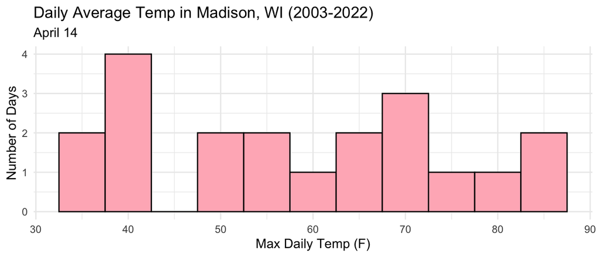

```r
ggplot(madison_high_apr_temps, aes(x = tmax)) +
  geom_histogram(binwidth = 5, fill = "lightpink", color = "black") +
  xlab("Max Daily Temp (F)") +
  ylab("Number of Days") +
  ggtitle("Daily Average Temp in Madison, WI (2003-2022)",
          subtitle = "April 14") +
  theme_minimal()
```

- Describe the distribution of daily maximum temperatures as shown by the graph. Is the distribution strongly skewed? Are there unusual measurements?

> The distribution of daily maximum temperatures is not normally distributed, as the distribution is slightly skewed to the right (the right-tail has more variation than the right tail). Seeing as this is likely not meant to be a normal distribution, there aren’t any overly unusual measurements, but it is of note that the most common daily max temp fell between 37.5 and 42.5 degrees F.

**2.** Compare the standard normal distribution with the t distribution with 19 degrees of freedom.

- Calculate the 0.975 quantiles from each of these two distribution.
- On the same graph, display the density functions of these two distributions, using blue for normal and red for t.
  - Add colored (use the same color scheme) dashed vertical lines at the corresponding 0.975 quantiles.
  - Shade the area in tail areas below the 0.025 and above the 0.975 quantiles of each distribution, setting `alpha = 0.5` for partial transparency.

```r
norm_dis = qnorm(0.975)
norm_dis
```

```
## [1] 1.959964
```

```r
t_dis = qt(0.975, 19)
t_dis
```

```
## [1] 2.093024
```

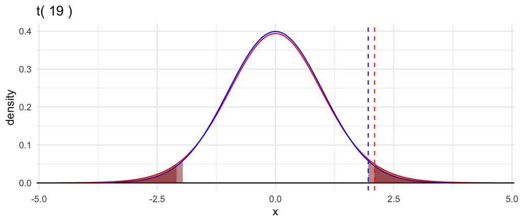

```r
gt(19, color = "red") +
  geom_norm_density(0, 1, color = "blue") +
  geom_norm_fill(0, 1, a = NULL, b = qnorm(0.025), alpha = 0.5) +
  geom_norm_fill(0, 1, a = norm_dis, b = NULL, alpha = 0.5) +
  geom_t_fill(19, a = NULL, b = qt(0.025, 19), alpha = 0.5) +
  geom_t_fill(19, a = t_dis, b = NULL, alpha = 0.5) +
  geom_vline(xintercept = t_dis, color = "red", linetype = "dashed") +
  geom_vline(xintercept = norm_dis, color = "blue", linetype = "dashed")
```

**3.** Using the data from Problem 1:

- Construct a 95% confidence interval for $\mu$ using the theory of the t distribution by direct calculation using the summary statistics from the first part of the problem.

```r
ci_calc = madison_high_apr_temps_sum %>%
  mutate(se = sd/sqrt(n),
         tmult = qt(0.975, n-1),
         me = tmult*se,
         low = mean - me,
         high = mean + me)

ci = ci_calc %>%
  select(low, high)

ci
```

```
## # A tibble: 1 × 2
##     low  high
##   <dbl> <dbl>
## 1  50.4  65.4
```

- Then use the `t.test()` function to verify your calculation.

```r
x = madison_high_apr_temps %>%
  pull(tmax)

t.test(x)
```

```
##
##  One Sample t-test
##
## data:  x
## t = 16.124, df = 19, p-value = 1.534e-12
## alternative hypothesis: true mean is not equal to 0
## 95 percent confidence interval:
##  50.38426 65.41574
## sample estimates:
## mean of x
##      57.9
```

- Interpret the interval in context.

> We are 95% confident that the mean max temperature in Madison, WI on April 14 over the last 20 years (from 2003-2022) was between 50.38426 and 65.41574 degrees F.

**4.** The historical average daily high temperature in Madison in April prior to 2000 is 55.6 degrees Farhenheit. Let $\mu$ be the expected daily high temperature on April 14 in the past two recent decades.

- Use a hypothesis test to test if $\mu$ equals 55.6 degrees versus the alternative that it is different. Include all steps as in the lecture notes.

### Population and Sample

> The population is the max temperature across all days in the month of April in the past two recent decades (2003-2022), and the sample is the 20 accounts of daily max temperature on April 14 in the past two recent decades.

### Statistical Model

> Daily high temperature is $x_1, \ldots, x_n$ for $n = 20$; if modeling these times as a random sample from the larger population, Let $F$ be this unspecified distribution, $\mu$ be the mean, and $\sigma$ be the standard deviation.

$$X_i \sim F(\mu, \sigma), \quad i = 1, \ldots, n$$

### Hypotheses

$H_0: \mu = 55.6$  
$H_a: \mu \neq 55.6$

### Test Statistics

```r
mu = 55.6

madison_high_apr_temps_sum = madison_high_apr_temps_sum %>%
  mutate(tstat = (mean - mu)/(sd/sqrt(n)))

tstat = madison_high_apr_temps_sum %>%
  pull(tstat)

tstat
```

```
## [1] 0.6405167
```

### Sampling Distribution

- tstat with 19 degrees of freedom

### P-Value Calculation

```r
madison_high_apr_temps_sum = madison_high_apr_temps_sum %>%
  mutate(pvalue = (1 - pt(tstat, n-1)) * 2)

pvalue = madison_high_apr_temps_sum %>%
  pull(pvalue)

madison_high_apr_temps_sum
```

```
## # A tibble: 1 × 5
##       n  mean    sd tstat pvalue
##   <int> <dbl> <dbl> <dbl>  <dbl>
## 1    20  57.9  16.1 0.641  0.529
```

```r
pvalue
```

```
## [1] 0.5294866
```

- Create a data set with the latest date from January to June in each year where there was at least one inch of snow for the years 1903–1922 and 2003–2022.
- Use the **lubridate** function `yday()` to create a new variable `yday` by converting this date into the number of days after December 31.
- Add a variable named `period` which has the value `"early 1900s"` for years 1903–1922 and `"early 2000s"` for the years 2003–2022.

```r
madison_snow_100 = madison_weather %>%
  mutate(month = month(date, label = TRUE),
         year = year(date),
         yday = as.numeric(yday(date))) %>%
  filter(snow >= 1, month == "Jan" | month == "Feb" | month == "Mar" | month == "Apr" | month == "May"
         | month == "Jun") %>%
  filter(between(year, 1903, 1922) | between(year, 2003, 2022)) %>%
  group_by(year) %>%
  summarize(latest_date = max(yday)) %>%
  mutate(period = str_c("Early ", str_sub(year, 1, 2), "00s"))

madison_snow_100
```

```
## # A tibble: 40 × 3
##     year latest_date period
##    <dbl>       <dbl> <chr>
##  1  1903         111 Early 1900s
##  2  1904          74 Early 1900s
##  3  1905         111 Early 1900s
##  4  1906          95 Early 1900s
##  5  1907          97 Early 1900s
##  6  1908          50 Early 1900s
##  7  1909          68 Early 1900s
##  8  1910         113 Early 1900s
##  9  1911          96 Early 1900s
## 10  1912         109 Early 1900s
## # ℹ 30 more rows
```

- Calculate the sample size, the sample mean, and the sample standard deviation for each period.

```r
madison_snow_100_sum =  madison_snow_100 %>%
  group_by(period) %>%
  summarize(n = n(),
            mean = mean(latest_date),
            sd = sd(latest_date))

madison_snow_100_sum
```

```
## # A tibble: 2 × 4
##   period          n  mean    sd
##   <chr>       <int> <dbl> <dbl>
## 1 Early 1900s    20  84.0  19.8
## 2 Early 2000s    20  90.9  16.8
```

- Create a graph to compare these two distributions.

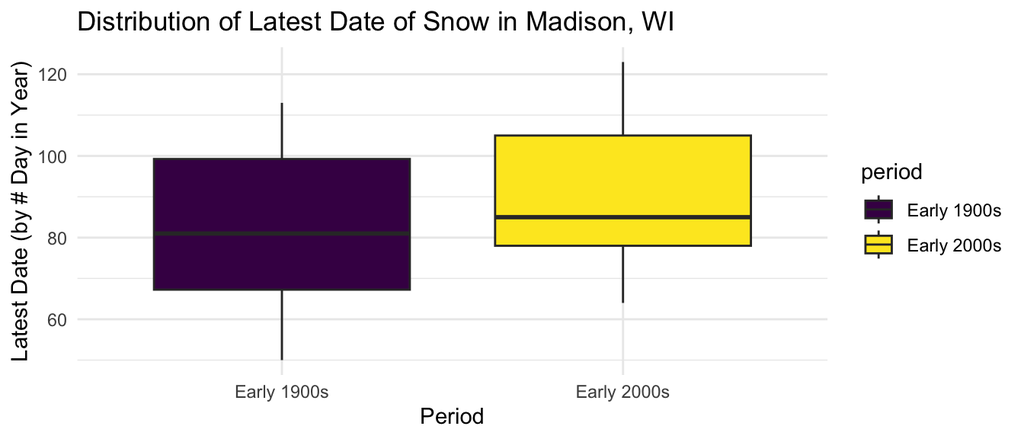

```r
ggplot(madison_snow_100, aes(x = period, y = latest_date, fill = period)) +
  geom_boxplot() +
  xlab("Period") +
  ylab("Latest Date (by # Day in Year)") +
  ggtitle("Distribution of Latest Date of Snow in Madison, WI")
```

**6.** Using the data from the previous problem:

```r
madison_1900 = madison_snow_100 %>%
  filter(period == "Early 1900s")

madison_2000 = madison_snow_100 %>%
  filter(period == "Early 2000s")

x = madison_1900 %>%
  pull(latest_date)

y = madison_2000 %>%
  pull(latest_date)

t.test(x, y)
```

```
##
##  Welch Two Sample t-test
##
## data:  x and y
## t = -1.1802, df = 37.047, p-value = 0.2454
## alternative hypothesis: true difference in means is not equal to 0
## 95 percent confidence interval:
##  -18.609478   4.909478
## sample estimates:
## mean of x mean of y
##     84.05     90.90
```

```r
t.test(x, y)
```

```
##
##  Welch Two Sample t-test
##
## data:  x and y
## t = -1.1802, df = 37.047, p-value = 0.2454
## alternative hypothesis: true difference in means is not equal to 0
## 95 percent confidence interval:
##  -18.609478   4.909478
## sample estimates:
## mean of x mean of y
##     84.05     90.90
```

**7.** Using the Boston Marathon data, treat the finishing times of men aged 35–39 in 2010 as a sample from a larger population of men worldwide who could have completed the Boston marathon that year.

```r
boston_marathon = read_csv("../../data/boston-marathon-data.csv")
```

- Calculate a numerical summary of the times to finish the race from this sample, including the sample size, sample mean, sample standard deviation, and the 0.10, 0.25, 0.50, 0.75, and 0.90 quantiles.

```r
boston_men_3539_2010 = boston_marathon %>%
  filter(Sex == "male",
         Age_Range == "35-39",
         Year == 2010)

boston_men_3539_2010
```

```
## # A tibble: 1,769 × 15
##    BibNum  Year Sex     Age Age_Range  Time `K0-5` `K5-10` `K10-15` `K15-20`
##     <dbl> <dbl> <chr> <dbl> <chr>     <dbl>  <dbl>   <dbl>    <dbl>    <dbl>
##  1     17  2010 male     35 35-39      135.   14.9    15.2     14.9     15.2
##  2     40  2010 male     36 35-39      146.   16.4    16.6     16.6     16.9
##  3     47  2010 male     35 35-39      146.   16.4    16.7     16.8     17.0
##  4   1009  2010 male     35 35-39      151.   16.6    17.0     17.2     17.5
##  5   1010  2010 male     35 35-39      163.   18.8    19.4     19.3     19.6
##  6   1034  2010 male     36 35-39      144.   16.8    17.3     16.9     17.0
##  7   1036  2010 male     38 35-39      146    16.6    17.2     17.3     17.3
##  8   1044  2010 male     35 35-39      145.   16.6    16.6     16.6     16.9
##  9   1054  2010 male     36 35-39      151.   17.0    17.5     17.6     18.0
## 10   1065  2010 male     35 35-39      166.   18.6    18.9     19.0     19.0
## # ℹ 1,759 more rows
## # ℹ 5 more variables: `K20-25` <dbl>, `K25-30` <dbl>, `K30-35` <dbl>,
## #   `K35-40` <dbl>, `K40-Fin` <dbl>
```

```r
boston_men_3539_2010_sum = boston_men_3539_2010 %>%
  summarize(n = n(),
            mean = mean(Time),
            sd = sd(Time),
            q10 = quantile(Time, 0.10),
            q25 = quantile(Time, 0.25),
            q50 = quantile(Time, 0.50),
            q75 = quantile(Time, 0.75),
            q90 = quantile(Time, 0.90))

boston_men_3539_2010_sum
```

```
## # A tibble: 1 × 8
##       n  mean    sd   q10   q25   q50   q75   q90
##   <int> <dbl> <dbl> <dbl> <dbl> <dbl> <dbl> <dbl>
## 1  1769  214.  38.5  177.  189.  202.  230.  272.
```

- Choose a type of graph and display the distribution of the sample finish times.

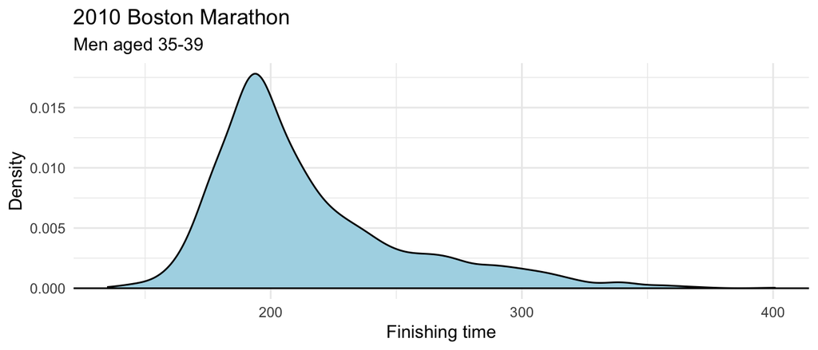

```r
ggplot(boston_men_3539_2010, aes(x = Time)) +
  geom_density(fill = "lightblue", color = "black") +
  geom_hline(yintercept = 0) +
  xlab("Finishing time") +
  ylab("Density") +
  ggtitle("2010 Boston Marathon",
          subtitle = "Men aged 35-39") +
  theme_minimal()
```

- Find a 95% confidence interval for the mean finishing time in the population using methods of the t distribution by direct calculation

```r
ci_calc = boston_men_3539_2010_sum %>%
  mutate(se = sd/sqrt(n),
         tmult = qt(0.975, n-1),
         me = tmult*se,
         low = mean - me,
         high = mean + me)

ci = ci_calc %>%
  select(low, high)

ci
```

```
## # A tibble: 1 × 2
##     low  high
##   <dbl> <dbl>
## 1  212.  216.
```

- Repeat the calculations using the `t.test()` function

```r
x = boston_men_3539_2010 %>%
  pull(Time)

t.test(x)
```

```
##
##  One Sample t-test
##
## data:  x
## t = 233.88, df = 1768, p-value < 2.2e-16
## alternative hypothesis: true mean is not equal to 0
## 95 percent confidence interval:
##  212.2629 215.8531
## sample estimates:
## mean of x
##   214.058
```

- Interpret this confidence interval in context following the format of examples from lecture.

> We are 95% confident that the mean finishing time of men aged 35-39 capable of finishing the Boston Marathon in 2010 would have been between 212.2629 and 215.8531 minutes.

**8.** Treat the finishing times in the Boston Marathon of men aged 35–39 in 2010 and 2011 as two different independent samples. Is there evidence that the mean time to finish the race among a population of potential finishers changed during these two years? Conduct a hypothesis test to support your conclusion.

## Hypothesis Test

- State Hypotheses

$H_0: \mu_1 = \mu_2$  
$H_a: \mu_1 \neq \mu_2$

- Test statistic $t = \frac{\bar{x} - \bar{y}}{\text{SE}(\bar{x} - \bar{y})}$

```r
boston_men_3539_2011 = boston_marathon %>%
  filter(Sex == "male",
         Age_Range == "35-39",
         Year == 2011)

t.test(boston_men_3539_2010$Time, boston_men_3539_2011$Time)
```

```
##
##  Welch Two Sample t-test
##
## data:  boston_men_3539_2010$Time and boston_men_3539_2011$Time
## t = 1.2249, df = 3608.6, p-value = 0.2207
## alternative hypothesis: true difference in means is not equal to 0
## 95 percent confidence interval:
##  -0.9477035  4.1031083
## sample estimates:
## mean of x mean of y
##  214.0580  212.4803
```